# R Notebook

Question 5 Check if your data is stationary using the appropriate plots. Do you have stationary data? If no, make the data stationary.

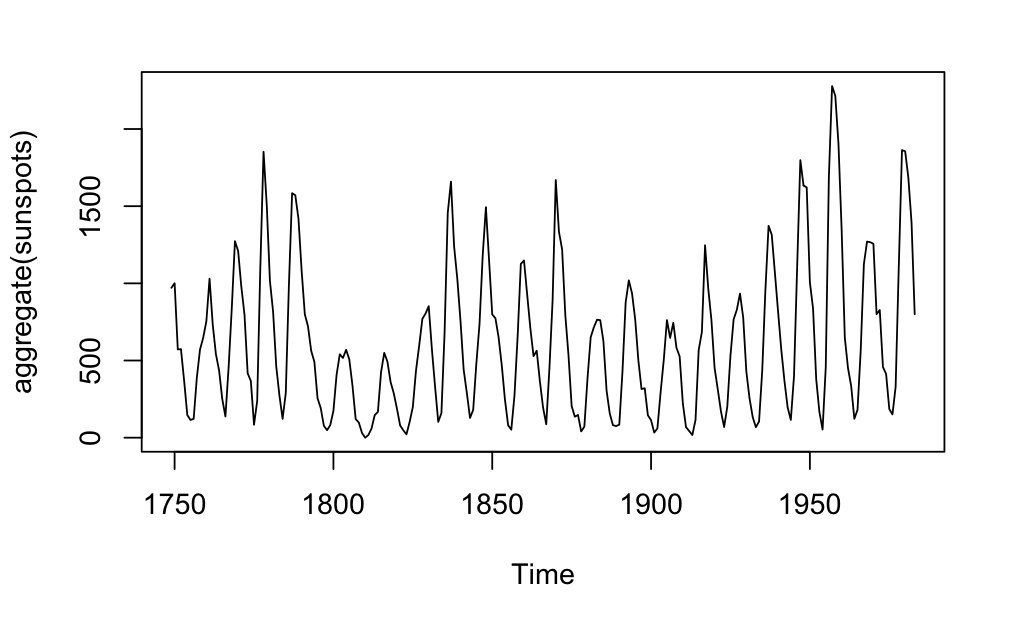

```r
# We already know that the year on year mean trend

plot(aggregate(sunspots), fun = mean)
```

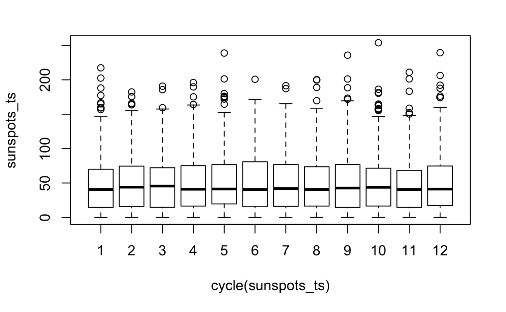

```r
boxplot(sunspots_ts~cycle(sunspots_ts))
```

```r
adf.test(sunspots_ts, alternative="stationary", k=0)
```

```
p-value smaller than printed p-value
```

```
    Augmented Dickey-Fuller Test

data:  sunspots_ts
Dickey-Fuller = -10.843, Lag order = 0, p-value = 0.01
alternative hypothesis: stationary
```

p_value is low, we can reject the null hypothesis and confirm that the data is sationary.

Question 6 Now we have our data, choose your ARIMA model parameters. Create ACF and PACF plots to check, and write a summary of what you have found.

```r
arimaAP <- auto.arima(sunspots_ts, approximation = FALSE)
arimaAP
```

```
Series: sunspots_ts
ARIMA(2,1,2)

Coefficients:
         ar1      ar2      ma1     ma2
      1.3467  -0.3963  -1.7710  0.8103
s.e.  0.0303   0.0287   0.0205  0.0194

sigma^2 estimated as 243.8:  log likelihood=-11745.5
AIC=23500.99   AICc=23501.01   BIC=23530.71
```

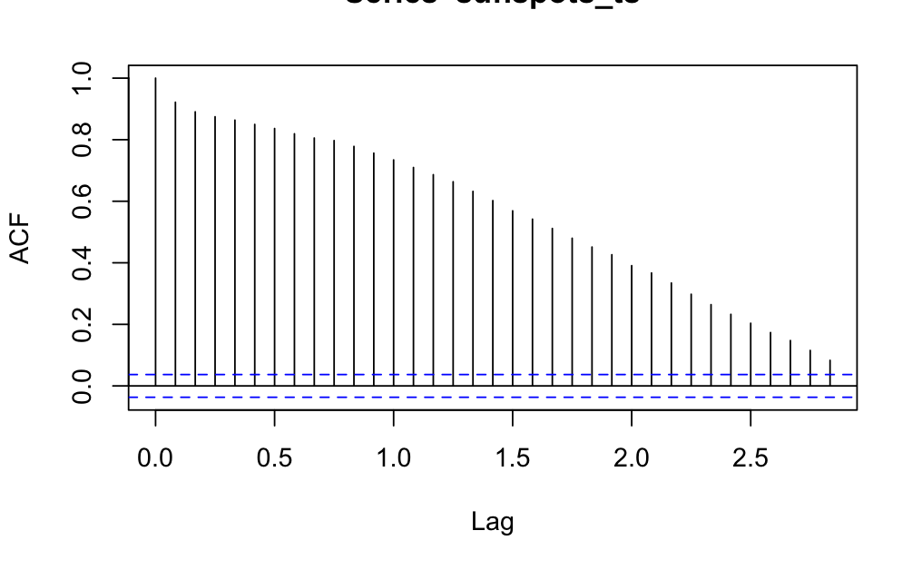

```r
acf(sunspots_ts)
```

I must have missed something here….

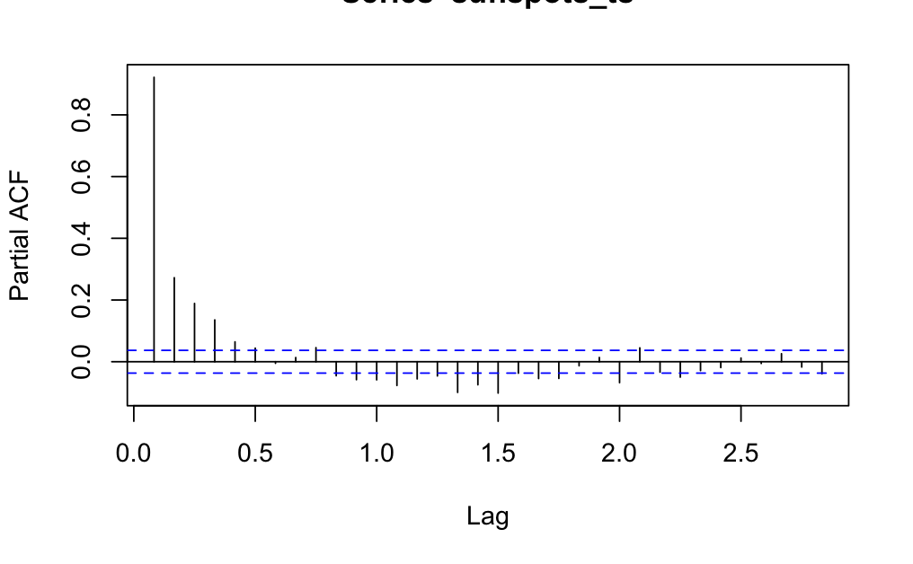

```r
pacf(sunspots_ts)
```

Question 7 Fit an ARIMA model that predicts the sunspots for the next 20 years. Plot the data, and have a look at your forecast. Does it look like a good forecast or good fit?

```r
model_1 <- arima(sunspots_ts, c(2,1,2),seasonal = list(order = c(2,1,2), period = 12))
```

```
restarting interrupted promise evaluationrestarting interrupted promise evaluationpossible convergence problem: optim gave code = 1
```

```r
model_1
```

```
Call:
arima(x = sunspots_ts, order = c(2, 1, 2), seasonal = list(order = c(2, 1, 2),
    period = 12))

Coefficients:
         ar1      ar2      ma1     ma2    sar1    sar2     sma1    sma2
      1.3520  -0.3962  -1.7726  0.8090  0.4454  -0.061  -1.4236  0.4280
s.e.  0.0321   0.0296   0.0214  0.0203  0.5108   0.020   0.5082  0.5073

sigma^2 estimated as 243.7:  log likelihood = -11722.15,  aic = 23462.3
```

```
    Ljung-Box test

data:  Residuals from ARIMA(2,1,2)(2,1,2)[12]
Q* = 41.819, df = 16, p-value = 0.0004198

Model df: 8.   Total lags used: 24
```

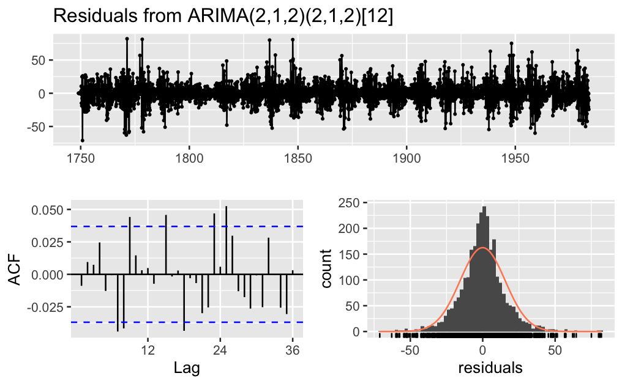

```r
# checking the residuals
checkresiduals(model_1)
```

There seem to be an issue with the model although the residuals plot look ok

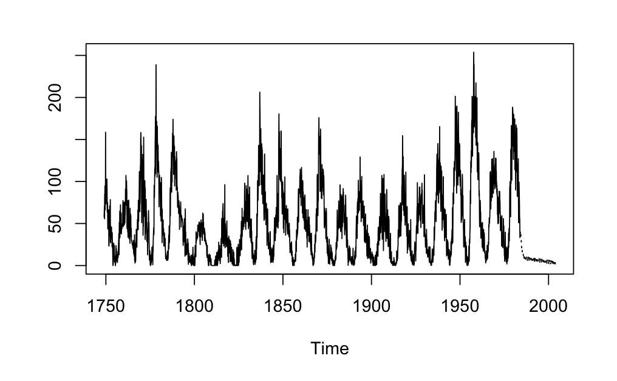

```r
predictions <- predict(model_1, n.ahead = 20*12)

# plot the air passengers data, along with the predicted data
ts.plot(sunspots, predictions$pred, lty = c(1,3))
```

Definitly doesn’t look like a good model

Question 8 Problem solving: Your model isn’t predicting that well. What are some reasons you can think for this?

```r
# From the acf graph we can see that everything seem to be significant.
# There must be some ynderlying correlation that I have forgotten about.
```

Question 9 Problem solving:

In the present case, sunspots have a cycle of length 11 years. To know this, you’d have to know something about sunspots. You can find this here. The sunspots data are a monthly time series. Thus, the implicit seasonality of sunspots is 12 (months), not 11×12=132 (months).

ARIMA and auto.arima() were never built to automatically detect a seasonal cycle whose length is not pre-specified. It is not overly surprising it does not see that it should do 11 seasonal differences to model a seasonality that repeats every 11 cycles of its prespecified frequency.

Extensions Question 1 The dataset, sunspot.month is a ts class, rather than a classic tidy tibble. Using your knowledge of tidyverse and ts objects, convert the sunspot.month data to a tidy data set using the tk_tbl() function from timetk package. Using this instead of as.tibble() (from the tibble package) is better because it automatically preserves the time series index.

Then, convert the index to date using lubridate::as_date() and then change to a tbl_time object (from the tibbletime package).

Then summarise the median value of sunspots in the year 1980. Hint: you’ll have to combine your knowledge of how to filter and summarise dates and times in tidyverse to do this.

Question 2 Get and load the package ‘xts’ and all required packages. Create the objects ‘measurment’ and ‘dates’ like below.

measurement <- rep(sin(seq(0,10,length.out = 90)),4) + rnorm(90*4) dates <- seq(as.Date(“1987-01-01”), as.Date(“1987-12-26”), “day”) Use the two objects to create an xts time series (mytimeseries) ordered by dates. Check the class, structure, number of years, months and quarters. Get the core data and index as well, and check these are matrix and index data.

Select all of the August to September data in your xts object. Plot this new xts time series.Use apply.monthly from xts to get a monthly mean on the time series. Finally, get a monthly plot.